# 2. Visualizations using caret

Russ Conte

4/29/2022

The `featurePlot` function is a wrappter for different `lattice` plots to visualize the data. For example, the following figures show the default plot for continuous outcomes generated using the `featurePlot` function.

For classification data sets, the `iris` data are used for illustration.

```r
str(iris)
```

```
## 'data.frame':    150 obs. of  5 variables:
##  $ Sepal.Length: num  5.1 4.9 4.7 4.6 5 5.4 4.6 5 4.4 4.9 ...
##  $ Sepal.Width : num  3.5 3 3.2 3.1 3.6 3.9 3.4 3.4 2.9 3.1 ...
##  $ Petal.Length: num  1.4 1.4 1.3 1.5 1.4 1.7 1.4 1.5 1.4 1.5 ...
##  $ Petal.Width : num  0.2 0.2 0.2 0.2 0.2 0.4 0.3 0.2 0.2 0.1 ...
##  $ Species     : Factor w/ 3 levels "setosa","versicolor",..: 1 1 1 1 1 1 1 1 1 1 ...
```

### Scatterplot Matrix

This first block of code loads all the required packages in two lines - nice and clean!

```r
Packages = c("AppliedPredictiveModeling", "caret", "tidyverse", "mlbench")
lapply(Packages, library, character.only = TRUE)
```

[output not shown]

[output cut: 22 more lines]

Let’s create the scatterplot matrix for the iris data set!

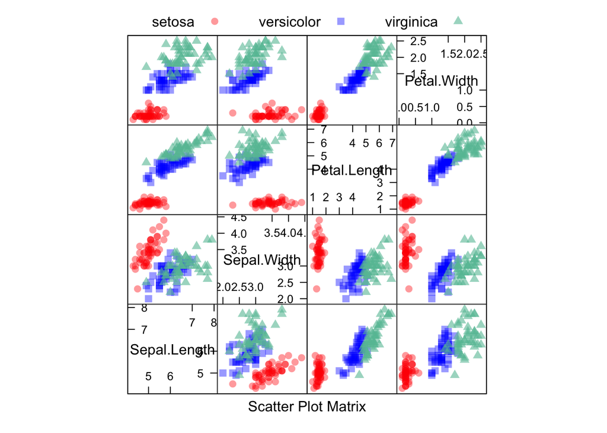

```r
transparentTheme(trans = 0.4)
featurePlot(x = iris[,1:4],
            y = iris$Species,
            plot = "pairs",
            ## Add a key at the top to list the names of the irises
            auto.key = list(columns = 3))
```

### Scatterplot Matrix with Ellipses

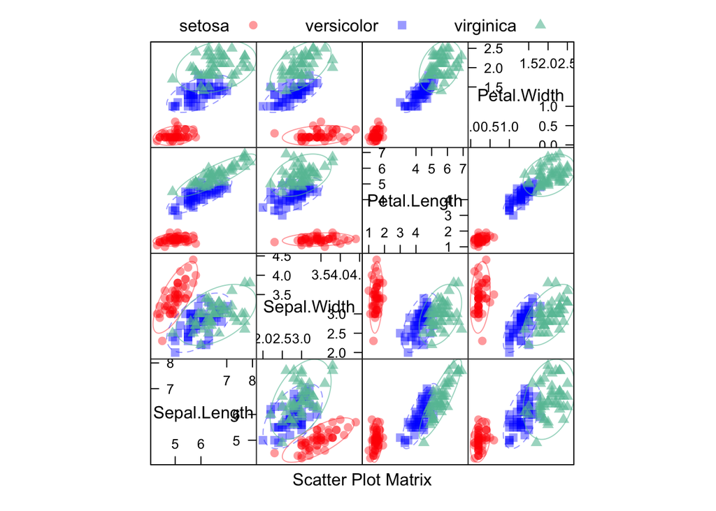

```r
featurePlot(x = iris[,1:4],
             y = iris$Species,
            plot = "ellipse",
            ## Add a key at the top of the data visualization
            auto.key = list(columns = 3))
```

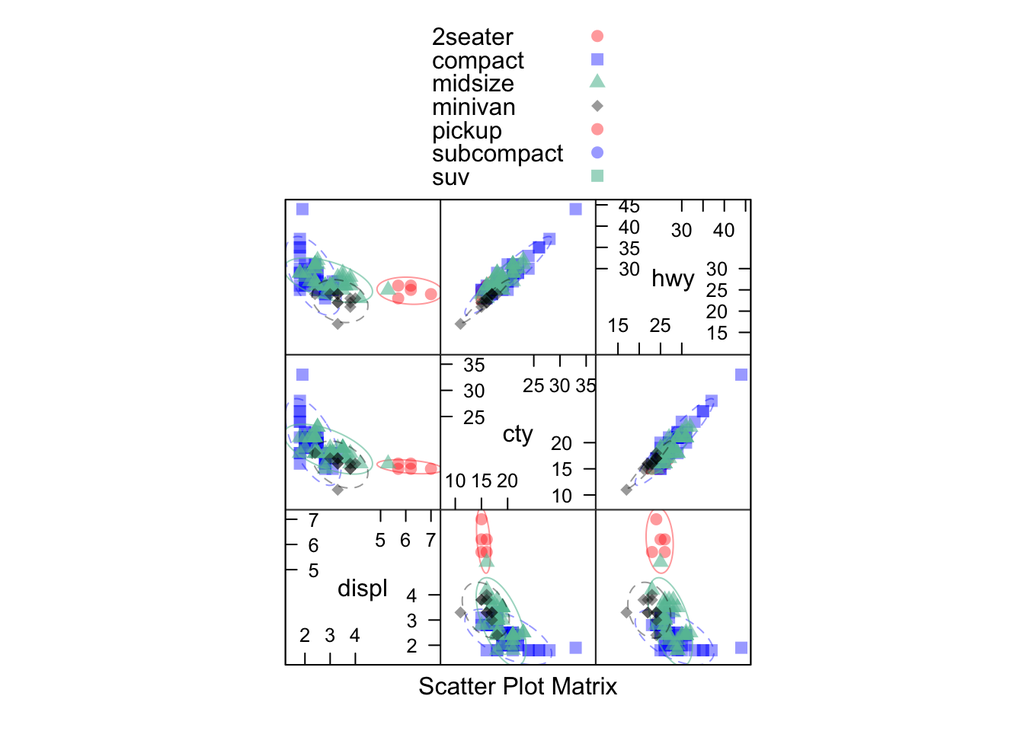

```r
# A working example of the same solution using the mpg data set from tidyverse:

mpg1 <- mpg %>%
  mutate(class = as.factor(class)) # convert y-hat to a factor

featurePlot(x = mpg1[,c(3,8:9)],
            y = mpg1$class,
            plot = "ellipse",
            auto.key = list(7))
```

### Overlayed Density Plots (I like these a lot!)

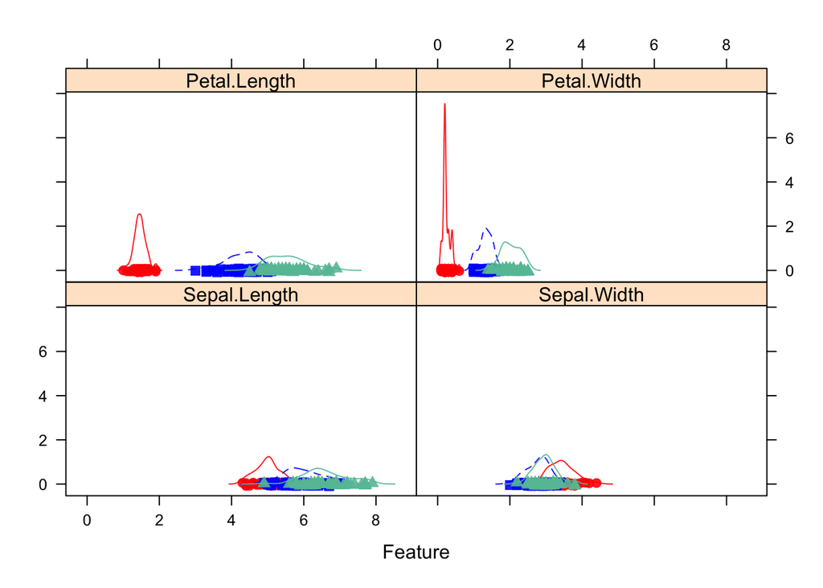

```
featurePlot(x = iris[,1:4],
            y = iris$Species,
            plot = "density",
            scales = list(x = list(relation = "free"),
                          y = list(relation = "free")),
            adjust = 1.5,
            pch = "|",
            layout = c(4,1),
            auto.key = list(columns = 3))
```

```r
transparentTheme(trans = 0.9)
featurePlot(x = iris[1:4],
            y = iris$Species,
            plot = "density")
```

Repeat similar exercise for density plots using mpg data set from tidyverse:

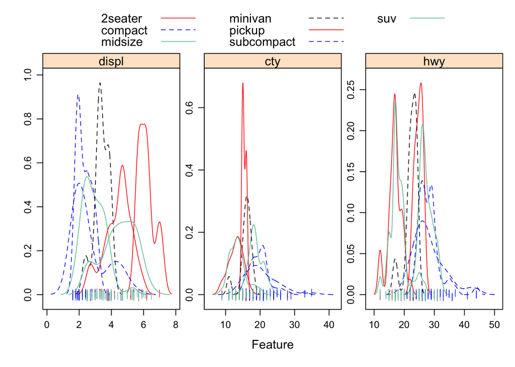

```r
featurePlot(x = mpg1[,c(3,8:9)],
            y = mpg1$class,
            plot = "density",
            scales = list(x = list(relation = "free"),
                          y = list(relation = "free"),
            adjust = 1.5),
            pch = "|",
            auto.key = list(columns = 3)) # creates three columns for the labels - nice!
```

### Box plots

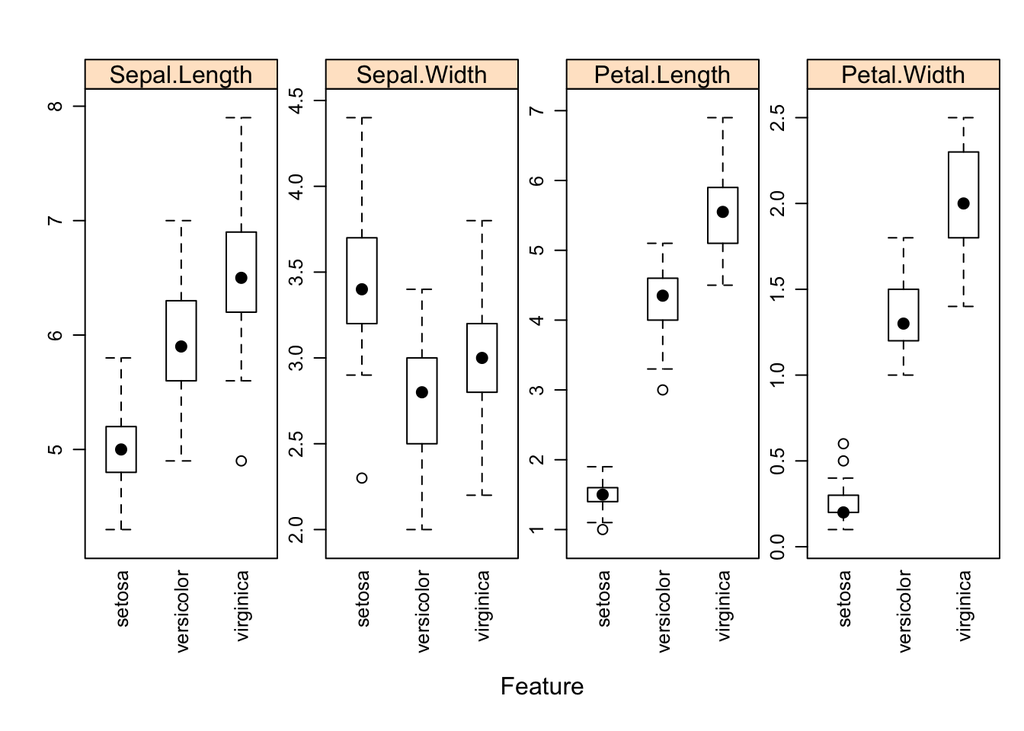

```r
featurePlot(x = iris[,1:4],
            y = iris$Species,
            plot = "box",
# pass in options to bwplot()
            scales = list(y = list(relation = "free"),
                          x = list(rot = 90)),
            layout = c(4,1),
            auto.key = list(columns = 2))
```

Repeat similar exercise for box plots using mpg data from tidyverse:

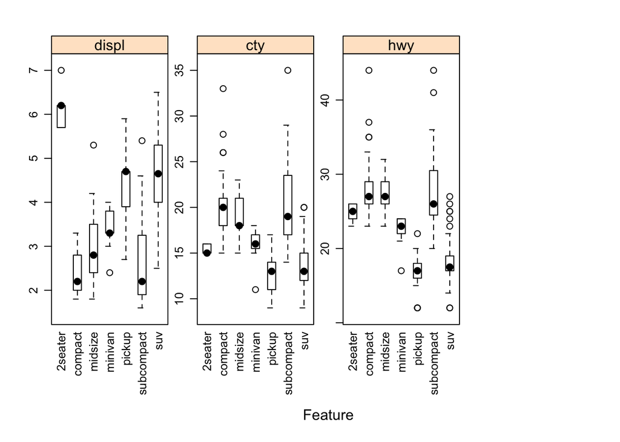

```r
featurePlot(x = mpg1[,c(3, 8:9)],
            y = mpg1$class,
            plot = "box",
            scales = list(y = list(relation = "free"),
                          x = list(rot = 90)),
            layout = c(4,1),
            auto.key = list(columns = 2))
```

### Scatter Plots

For regression, we’ll start with the Boston housing data set:

```r
data("BostonHousing")
regVar <- c("age", "lstat", "tax")
str(BostonHousing[, regVar])
```

```
## 'data.frame':    506 obs. of  3 variables:
##  $ age  : num  65.2 78.9 61.1 45.8 54.2 58.7 66.6 96.1 100 85.9 ...
##  $ lstat: num  4.98 9.14 4.03 2.94 5.33 ...
##  $ tax  : num  296 242 242 222 222 222 311 311 311 311 ...
```

When the predictors are continuous, `featurePlot` can be used to create scatter plots of each of the predictors with the outcome. For example:

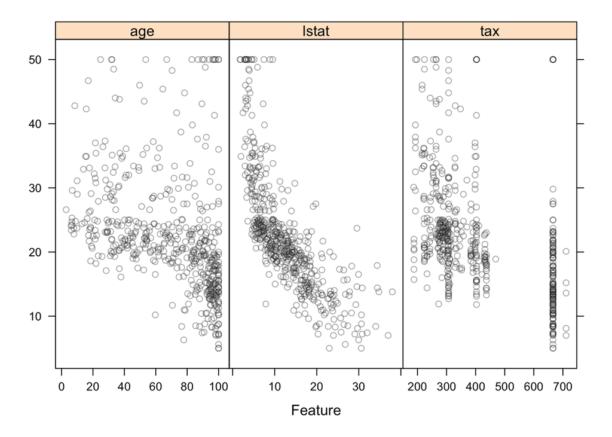

```r
theme1 <- trellis.par.get()
theme1$plot.symbol$col = rgb(.2, .2, .2, .4)
theme1$plot.symbol.pch = 16
theme1$plot.line$col = rgb(1,0,0,.7)
theme1$plot.line$lwd <- 2
trellis.par.set(theme1)
featurePlot(x = BostonHousing[,regVar],
            y = BostonHousing$medv,
            plot = "scatter",
            layout = c(3,1))
```

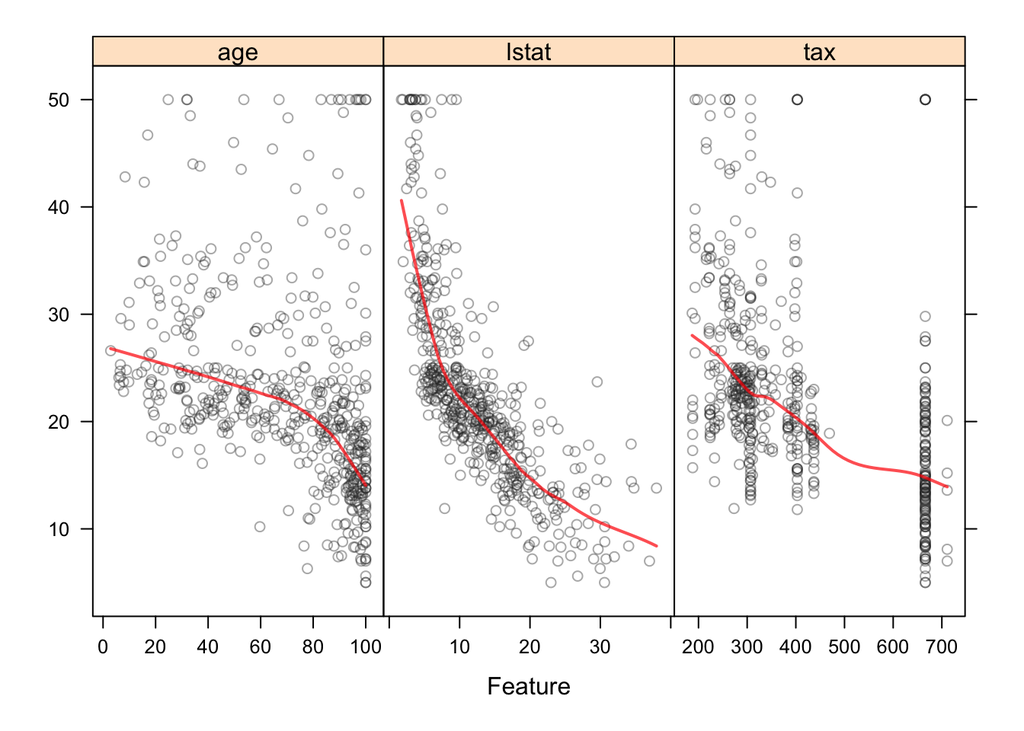

```r
featurePlot(x = BostonHousing[, regVar],
            y = BostonHousing$medv,
            plot = "scatter",
            type = c("p","smooth"),
            span = 0.5,
            layout = c(3,1))
```

Note that the options `degree` and `span` control the smoothness of the smoother.

Let’s create a feature plot with the continuous variables in the mpg data set. Let’s predict and plot highway mileage given the four other continuous values in the data set:

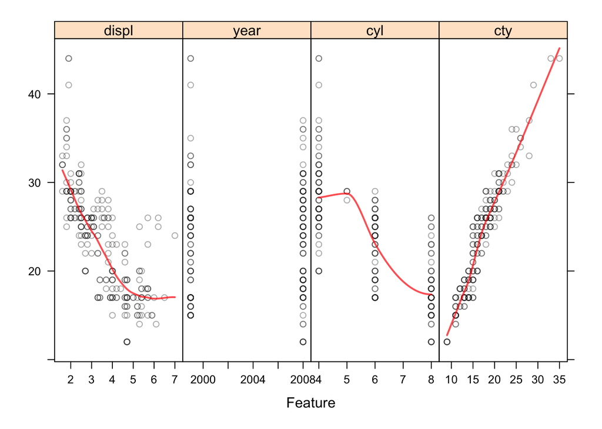

```r
featurePlot(x = mpg1[,c(3:5,8)],
            y = mpg1$hwy,
            plot = "scatter",
            type = c("p", "smooth"),
            span = 0.5,
            layout = c(4,1))
```

Summary of the graph: Clearly the city mileage is the strongest predictor of the four for highway mileage.

This completes chapter 2, Visualizations, it was a lot of fun, and I learned a lot (as always!)